# Causal Prior Recovery

Derek Powell

May 26, 2018

Researchers studying causal learning most commonly examine how people learn causal relationships from observing covarations among events. This has borne a lot of fruit and touched on some deep philosophical issues about the nature of causality (e.g., it’s all in our heads!). However, little of the causal knowledge that most people actually possess is achieved in this way. Instead, most of our causal knowledge comes from what others tell us about the world. Of course, people rarely convey causal information like, “the causal power of aspirin to reduce headaches is .25.” Instead, we communicate more vague information, like “aspirin helps with headaches.” Moreover, we communicate and possess even more abstract understandings of how different types of causal entities interact and how different different causal mechanisms operate, that let us draw inferences about specific causal relationships from generalities. How do these forms of knowledge interact in our causal inferences?

This is a preliminary exploration for a project I’m considering that would examine how mechanistic understandings or explanations might shape people’s priors about causal relationships. The idea is that our abstract understanding of causal mechanisms could be expressed as different priors about the possible strengths of causal relationships. Given different cover stories suggesting different potential mechanisms, we should expect different kinds of observations. With that, the idea is to use [webppl](http://webppl.org) to combine *bayesian cognitive modeling* and *bayesian data analysis* to infer causal learner’s domain-specific priors based on their responses in a causal learning task. This would begin to suggest ways in which we might connect these two forms of causal knowledge.

This notebook is a preliminary proof-of-concept test to see whether this kind of approach could work. In this notebook, I’ll simulate some causal power estimates with a model of a causal learner. I’ll simualte data for two different sets of contingency data and with priors for two different contexts. Then, I’ll do bayesian data analysis over the bayesian cognitive model and we’ll see how well we can recover the original parameters.

# Simulate Responses

As an example, here I sample the posterior over expected occurrences of some effect E, given cause C and background causes B, after learning the contingency data below:

|  | B present, C absent | B present , C present |
| --- | --- | --- |
| E present | 2 | 8 |
| E absent | 8 | 2 |

Here I assume the causal learner has prior $Beta(3,3)$ over the causal strength of cause C, and uniform prior over causal strength of background causes. I’m simulating participants responses to the counterfactual causal strength questions:

> “Suppose cause [B/C] occurred alone 10 separate times, how many times would we observe the effect?”

Here’s the webppl code for the causal learner.

```javascript
var contingencies = dataFromR[0]

// a model for causal inference
var observerModel = function(priors){
  Infer({
    method:"rejection", samples:1000,

    model: function() {
      var cPower = sample(priors)
      var bPower = uniform({a:1,b:1})
      var causeModel = binomial({n:10, p:cPower+bPower-cPower*bPower})
      var backgroundModel = binomial({n:10, p:bPower})

      condition(backgroundModel==contingencies.e_notC)
      condition(causeModel==contingencies.e_C)
      var cGuess = binomial({n:10,p:cPower})
      var bGuess = binomial({n:10,p:bPower})
      return {C: cGuess, B: bGuess}
      }
    }
  )
}

observerModel(Beta({a:3,b:3}))
```

To get samplse, I do inference on the learner using rejection sampling to end up with 1000 simulated responses. Dividing the response by 10 approximates the causal strength judgment. Here’s a heatmap of the posterior causal powers of causes B and C.

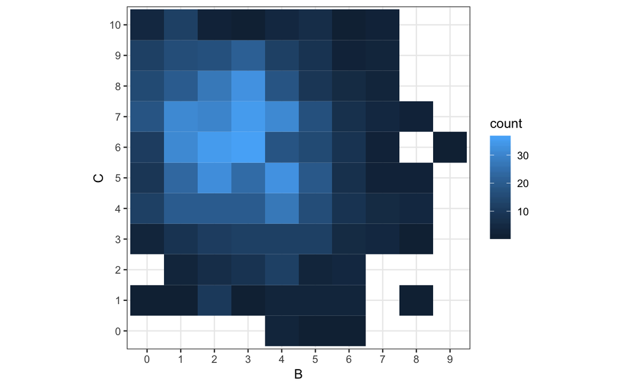

```r
conts <- data.frame(
  Ctrials = 10,
  notCtrials = 10,
  e_C = 8,
  e_notC = 2
)
resp_posterior <- webppl(
  program_file = "webppl/causalLearner.wppl",
  data = conts,
  data_var = "dataFromR"
)
resp_posterior %>%
  spread(Parameter, value) %>%
  mutate(
    B = as.factor(B),
    C = as.factor(C)
  ) %>%
  ggplot(aes(x = B, y = C)) +
  geom_bin2d() +
  theme_bw() +
  theme(aspect.ratio = 1)
```

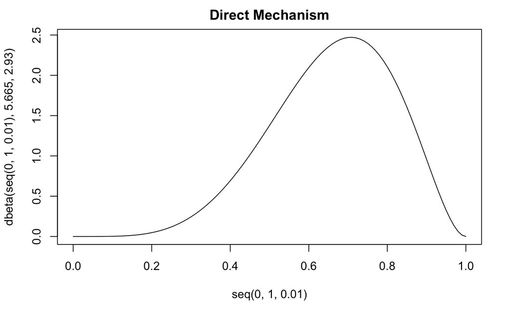

```r
plot(seq(0,1,.01), dbeta(seq(0,1,.01), 5.665, 2.93), type = "l")
title("Direct Mechanism")
```

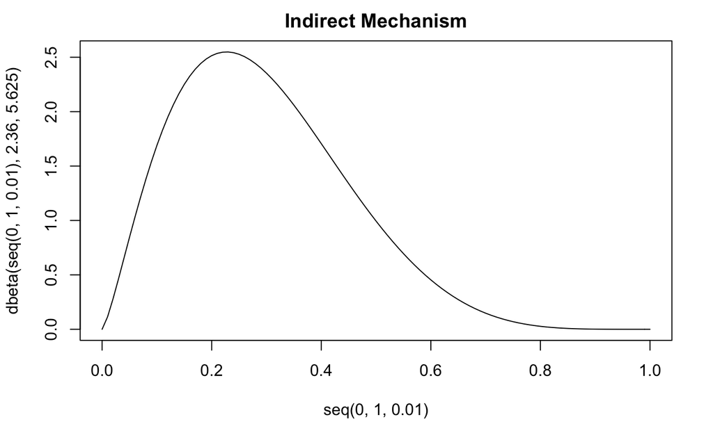

```r
plot(seq(0,1,.01), dbeta(seq(0,1,.01), 2.36, 5.625), type = "l")
title("Indirect Mechanism")
```

I’ll simulate data for four conditions, two contingency conditions (strong vs weak) where the power of cause C is manipulated, and two mechanism condiitons, where the priors are manipulated. In the experiment, this corresponds to the different cover stories. I’m simulating data for 100 Ps per condition (*n* = 400 total).

```r
# this is all pretty ugly but it works
cond_data <- data.frame(
  contingency = c("weak", "strong", "weak", "strong"),
  mechanism = c("direct", "direct", "indirect", "indirect"),
  Ctrials = c(10,10,10,10),
  notCtrials = c(10,10,10,10),
  e_C = c(4, 8, 4, 8),
  e_notC = c(2,2,2,2)
) %>%
  mutate(
    a_prior = if_else(mechanism=="direct", 5, 2),
    b_prior = if_else(mechanism=="direct", 2, 5)
    )
simulate_causal_reasoners <- function(data) {
  resps <- webppl(program_file = "webppl/causalLearner-func.wppl",
                packages = c("node_modules/discretizedBeta"),
                data=data,
                data_var="dataFromR") %>%
    select(Iteration, Parameter, value) %>%
    mutate(
      contingency = data$contingency,
      mechanism = data$mechanism,
      a_prior = data$a_prior,
      b_prior = data$b_prior,
      Ctrials = data$Ctrials,
      notCtrials = data$notCtrials,
      e_C = data$e_C,
      e_notC = data$e_notC
    ) %>%
    rename(response = value) %>%
    filter(Iteration %in% 1:100)
}
simulated_data = NULL
for (i in 1:nrow(cond_data)) {

  rowres <- simulate_causal_reasoners(cond_data[i,])
  if (is.null(simulated_data)){
    simulated_data <- rowres
  } else {
    simulated_data <- bind_rows(simulated_data, rowres)
  }
}
```

So now we have some simulated data. Let’s take a look at the distributions of responses.

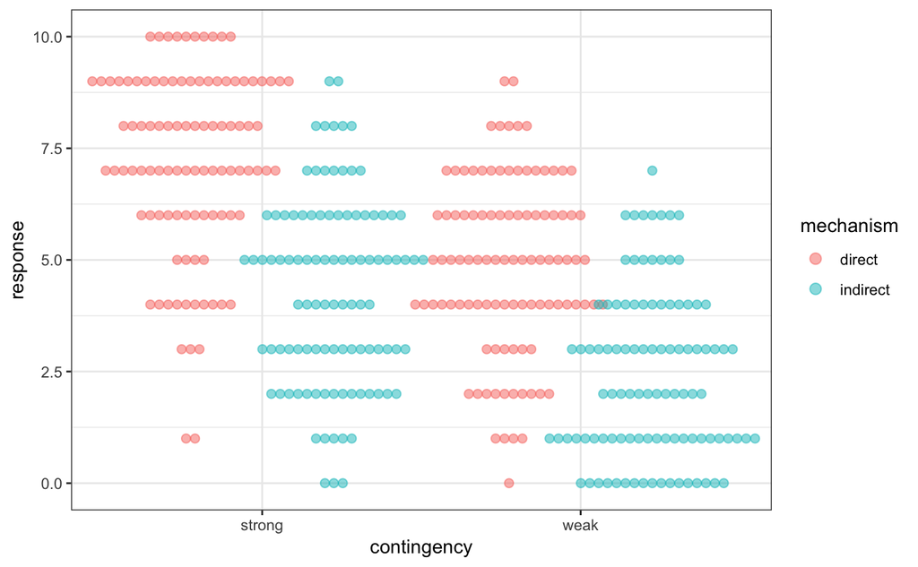

```r
simulated_data %>%
  filter(Parameter == "C") %>%
  ggplot(aes(y = response, x = contingency, fill = mechanism, color = mechanism)) +
  geom_dotplot(binaxis = "y", stackdir = "center", position = "dodge", alpha=.5, binwidth=.20) +
  theme_bw()
```

Ok, quite clearly we’re getting a substantial effect of priors (“mechanism”), and an effect of contingency as well.

# Inferring priors from responses

Now we’ll do bayesian data analysis over our bayesian cognitive model, and see if we can recover the parameters of the prior distributions.

Here’s the webppl code for the bayesian data analysis model.

```javascript
// A bayesian data analysis (BDA) model (bayes in the notebook)
var bdaModel = function() {

  //   set our prior over observers' priors
  //   here assuming prior is a beta distribution with unknown parameters

  var g1 = uniformDrift({a: 0, b: 1, width: 0.2});
  var d1 = uniformDrift({a: 0, b: 100, width: 20});

  var a1 = g1 * d1;
  var b1 = (1 - g1) * d1;

  var g2 = uniformDrift({a: 0, b: 1, width: 0.2});
  var d2 = uniformDrift({a: 0, b: 100, width: 20});

  var a2 = g2 * d2;
  var b2 = (1 - g2) * d2;


  // var priors = DiscretizedBeta({a:a, b:b});
  var priors = {
    direct: DiscretizedBeta({a:a1, b:b1}),
    indirect: DiscretizedBeta({a:a2, b:b2})
  };

//   2. do predictions, map observed responses (following tow model)

  var predictions = map(function(contingency){
    return(map(function(mechanism){

      // get data for each condition

      var condInfo = {
        contingency: contingency,
        mechanism: mechanism
      }

      var condData = _.filter(cmechData, condInfo)

      // get observer's observed contingencies for each condition
      var contingencies = {
        Ctrials: condData[0].Ctrials,
        notCtrials: condData[0].notCtrials,
        e_C: condData[0].e_C,
        e_notC: condData[0].e_notC
      }

      var modelPosterior = observerModel(priors[mechanism], contingencies);

      // map Ps responses to do BDA

      map(
        function(d){
          observe(modelPosterior, {cGuess:d.C, bGuess:d.B})
          // condition(sample(modelPosterior) == d.response)
        },
        condData);

      // return avg predicted resp for each cond)
      // return _.fromPairs([[contingency + "_" + mechanism, expectation(modelPosterior.cGuess)]])

    }, mechanism_conditions))
  }, contingency_conditions)

  // TO DO: add code to return avg predicted responses

  //   4. return prior parameters (and add predicted values too?)
  // return {prior_a:a,prior_b:b, mode:mode, k:k}; // alternate parameterization
  return {
    direct_a:a1,
    direct_b:b1,
    indirect_a:a2,
    indirect_b:b2
  };

};
```

```r
# new updates do inference for both priors in one bda model and additionally takes B responses into account
# TAKES ~30 MIN TO RUN!
modelFile <- "webppl/causalPriorModelBDA2.wppl"
input_data <- simulated_data %>%
  spread(Parameter, response)
result <- webppl(
  program_file = modelFile,
  packages = c("node_modules/discretizedBeta"),
  data = input_data,
  data_var = "cmechData",
  inference_opts = list(method = "MCMC",
                        samples = 5000,
                        burn = 2500),
  model_var = "bdaModel"
)
saveRDS(object = result, file = "result.rds")
```

```r
result %>%
  filter(grepl("parameters", Parameter)) %>%
  group_by(Parameter) %>%
  summarize(mean = mean(value))
```

| Parameter | mean |
| --- | --- |
| parameters.direct_a | 4.517241 |
| parameters.direct_b | 1.676765 |
| parameters.indirect_a | 1.973365 |
| parameters.indirect_b | 5.284618 |

We recover the parameters pretty well! Recall, they were $Beta(5, 2)$, and $Beta(2, 5)$. And this is from not all that much data (*n* = 400).

We can also take a peek at the posterior distributions of both parameters, across the two mechanism conditions.

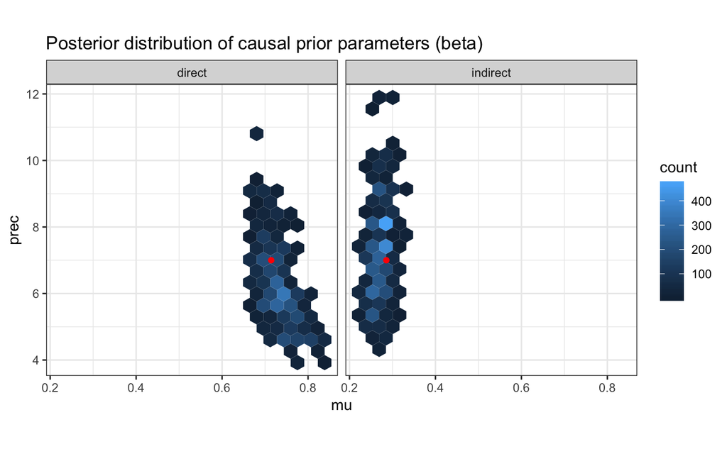

```r
result %>%
  filter(grepl("parameters", Parameter)) %>%
  mutate(
    mechanism = ifelse(grepl("indirect", Parameter), "indirect", "direct"),
    parameter =  ifelse(grepl("_a", Parameter), "A", "B")
    ) %>%
  select(-Parameter) %>%
  spread(parameter, value) %>%
  mutate(
    mu = A/(A+B),
    prec = A + B
    ) %>%
  ggplot(aes(x = mu, y = prec)) +
  geom_hex(bins=20) + # or geom_bin2d()
  geom_point(data = data.frame(mechanism = c("direct","indirect"), mu = c(5/7,2/7), prec=c(7,7)), color = "red") +
  facet_wrap(~mechanism, scales="fixed") +
  # geom_jitter(aes(color = mechanism), width = .1, height=.1, alpha=.33) + # alternate plotting approach
  theme_bw() +
  theme(aspect.ratio = 1) +
  labs(title = "Posterior distribution of causal prior parameters (beta)")
```

## MCMC diagnostics

Here are traceplots for parameters A and B, and in terms of mu and phi.

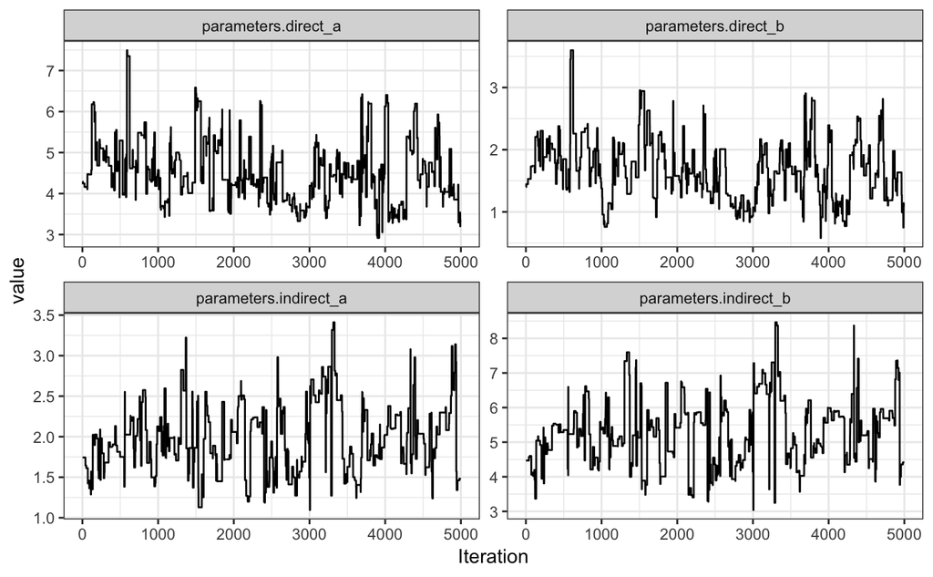

```r
result %>%
  filter(grepl("parameters", Parameter)) %>%
  ggplot(aes(x=Iteration, y = value)) +
  geom_line() +
  facet_wrap(~Parameter, scales="free") +
  theme_bw()
```

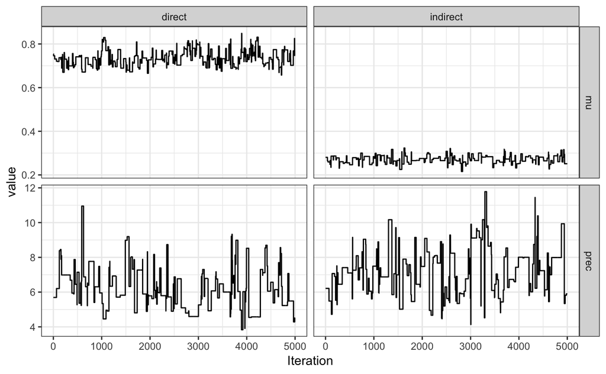

```r
result %>%
  filter(grepl("parameters", Parameter)) %>%
  mutate(
    mechanism = ifelse(grepl("indirect", Parameter), "indirect", "direct"),
    parameter =  ifelse(grepl("_a", Parameter), "A", "B")
    ) %>%
  select(-Parameter) %>%
  spread(parameter, value) %>%
  mutate(
    mu = A/(A+B),
    prec = A + B
    ) %>%
  select(-A, -B) %>%
  gather(parameter, value, mu, prec) %>%
  ggplot(aes(x=Iteration, y = value)) +
  geom_line() +
  facet_grid(vars(parameter), vars(mechanism),  scales = "free") +
  theme_bw()
```

They look reasonably good. Would probably be good to do more iterations though.

## Posterior predictive checks

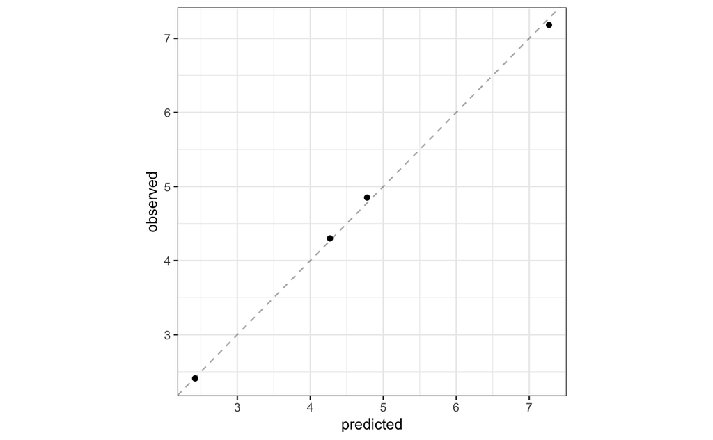

Only 4 data points but it gets an essentially perfect fit–as it should, since it’s fake data simulated from the true generating process.

## Conclusions

This is exciting and suggests this idea might be feasible and informative. Here I’ll throw a bit of water on things, and make a note that another, simpler approach would be to use something like a binned histogram task, ([see Franke et al., 2017 for an exploration](http://www.sfs.uni-tuebingen.de/~mfranke/Papers/FrankeDablander_2016_What_does_the_crowd_believe.pdf)), to directly ask people about their expectations, and then use those priors in a causal learning model to predict participants’ responses. However, these are probably complementary techniques, and it’s certainly cooler to use bayesian data analysis to uncover the priors inside the task.

**To do list …**

- add mcmc diagnostics (trace plots, etc) **DONE**
- add cause B responses to BDA model *doable, but not ultimately what I want I don’t think*
- return avg condition predicted responses **DONE**
- do both mechanism conditions in one go (separate sets of prior parameters) **DONE**
- investigate calculating likelihood, AIC, etc for models/data *can’t do it! but can do bayes factors between models*